# Clasificacion_Clientes_Rilo_v2

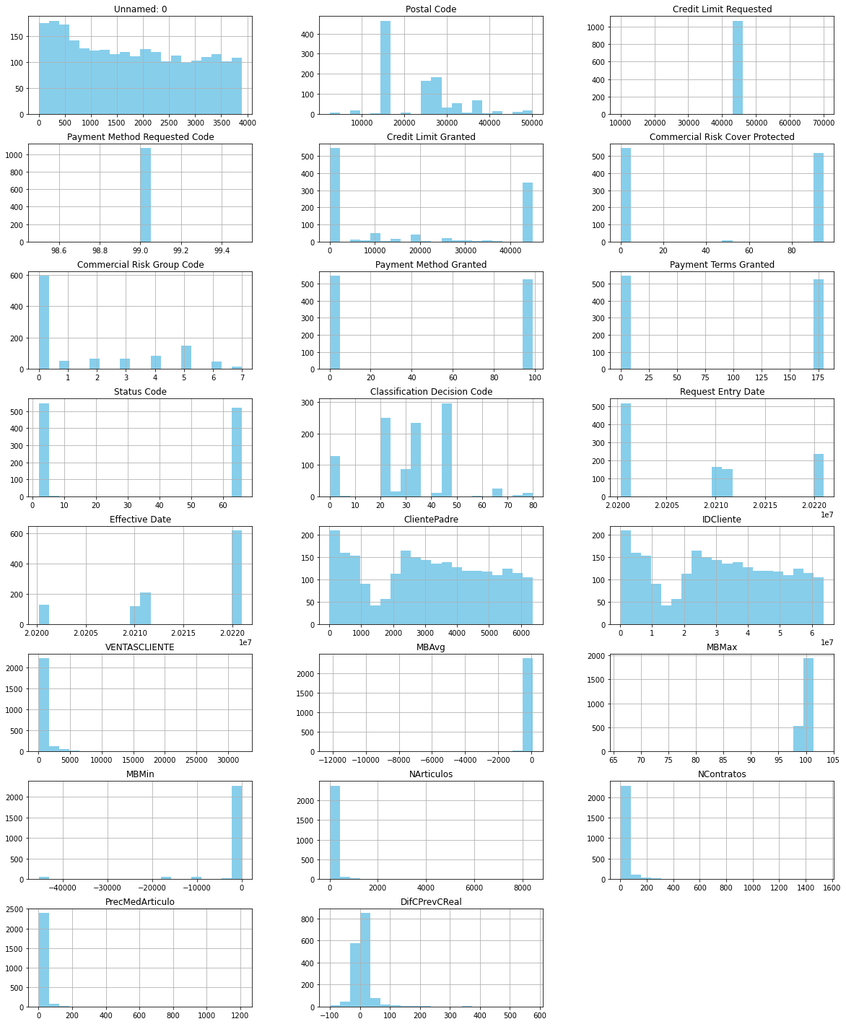

```python
df_Rilo_Clientes_Clean_2.hist(color='skyblue', bins=20, layout=(11,3), figsize=(20,35));
```

```python
df_Rilo_Clientes_Clean_2.shape
```

```
(2487, 27)
```

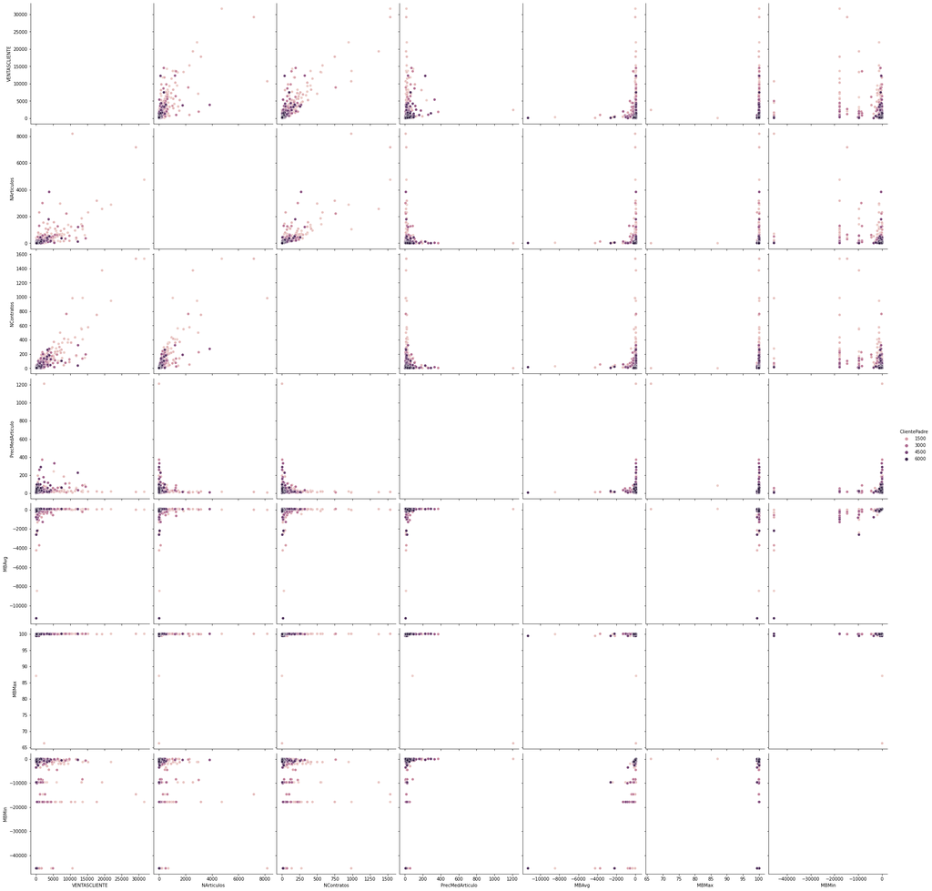

```python
sns.pairplot(df_Rilo_Clientes_Clean_2.dropna(), hue='ClientePadre',size=4,vars=["VENTASCLIENTE","NArticulos","NContratos","PrecMedArticulo","MBAvg","MBMax","MBMin"],kind='scatter')
```

```python
df_Rilo_Clientes_Clean_2.isna().sum()
```

```
Unnamed: 0                            0
City                               1436
State                              1423
Postal Code                        1418
Credit Limit Requested             1416
Payment Method Requested Code      1416
Credit Limit Granted               1416
Commercial Risk Cover Protected    1416
Commercial Risk Group Code         1416
Payment Method Granted             1416
Payment Terms Granted              1416
Status Code                        1416
Status                             1416
Classification Decision Code       1416
Classification Decision            1542
Request Entry Date                 1416
Effective Date                     1416
ClientePadre                          0
IDCliente                             0
VENTASCLIENTE                         0
MBAvg                                 0
MBMax                                 0
MBMin                                 0
NArticulos                            0
NContratos                            0
PrecMedArticulo                       0
DifCPrevCReal                       884
dtype: int64
```

Dado que despues de realizar el analisis exploratorio, descartar los clientes que pueden generar ruido y disponer de la muestra definitiva para analisis. Seguimos teniendo del contenido obtenido mediante el proveedor CESCE mas de 1400 registros con valores nulos.

Es por ello que realizaremos dos analisis para ver como se dispone la muestra. El primero de ellos solo con los datos obtenidos del ERP (sin NA) y posteriormente todo el dataset eliminando los valores nulos.

```python
df_Rilo_Clientes_ERP_clean = df_Rilo_Clientes_Clean_2.drop(['Unnamed: 0','City', 'Status',
                                              'ClientePadre','State','Postal Code','Credit Limit Requested','Payment Method Requested Code',
                                              'Credit Limit Granted','Commercial Risk Cover Protected','Commercial Risk Group Code','Payment Method Granted',
                                              'Payment Terms Granted','Status Code','Classification Decision Code','Classification Decision Code',
                                              'Classification Decision','Request Entry Date','Effective Date'], axis=1)
df_Rilo_Clientes_ERP_clean.head(5)
```

|  | IDCliente | VENTASCLIENTE | MBAvg | MBMax | MBMin | NArticulos | NContratos | PrecMedArticulo | DifCPrevCReal |
| --- | --- | --- | --- | --- | --- | --- | --- | --- | --- |
| 0 | 80002 | 4088.0932 | 32.83660 | 100.0 | -1206.010 | 692.5 | 224 | 15.130683 | -3.0 |
| 1 | 110007 | 830.1700 | -3.13485 | 100.0 | -816.492 | 121.0 | 121 | 6.860909 | -39.0 |
| 2 | 120003 | 392.2800 | 3.70088 | 100.0 | -630.395 | 21.5 | 19 | 20.356842 | 7.0 |
| 3 | 130030 | 2402.7208 | 73.62650 | 100.0 | -1206.010 | 373.0 | 165 | 11.935398 | 8.0 |
| 4 | 140010 | 2044.0675 | 31.62250 | 100.0 | -816.492 | 202.5 | 94 | 18.651462 | 0.0 |

```python
def impute_na(df, variable, mean_median):

    return df[variable].fillna(mean_median)
```

```python
median = df_Rilo_Clientes_ERP_clean['DifCPrevCReal'].median()

df_Rilo_Clientes_ERP_clean.loc[:,'DifCPrevCReal_median'] = impute_na(df_Rilo_Clientes_ERP_clean, 'DifCPrevCReal', median)
```

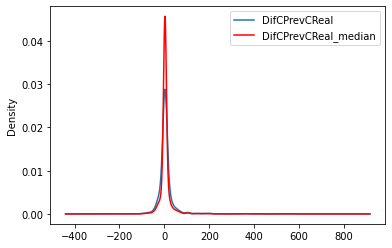

```python
fig = plt.figure()
ax = fig.add_subplot(111)

df_Rilo_Clientes_ERP_clean['DifCPrevCReal'].plot(kind='kde', ax=ax)

df_Rilo_Clientes_ERP_clean['DifCPrevCReal_median'].plot(kind='kde', ax=ax, color='red')

lines, labels = ax.get_legend_handles_labels()
ax.legend(lines, labels, loc='best')
```

```python
df_Rilo_Clientes_ERP_clean.isna().sum()
```

```
IDCliente                 0
VENTASCLIENTE             0
MBAvg                     0
MBMax                     0
MBMin                     0
NArticulos                0
NContratos                0
PrecMedArticulo           0
DifCPrevCReal           884
DifCPrevCReal_median      0
dtype: int64
```

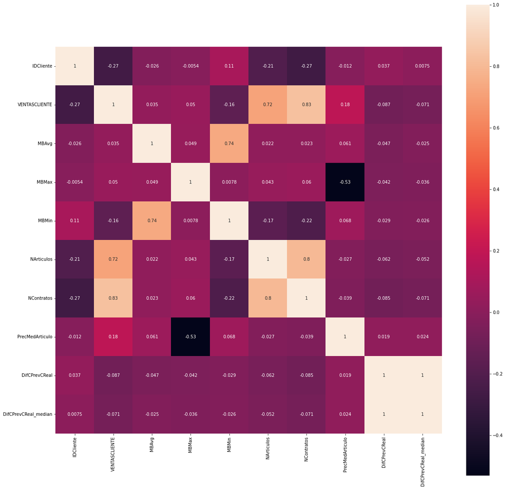

```python
corr = df_Rilo_Clientes_ERP_clean.corr()
corr.shape

plt.figure(figsize=(20,20))
sns.heatmap(corr, cbar=True, square=True, annot=True)
```

```python
df_Rilo_Clientes_ERP_clean_2 = df_Rilo_Clientes_ERP_clean.drop(['MBAvg','MBMax','MBMin','DifCPrevCReal','DifCPrevCReal_median'], axis=1)
df_Rilo_Clientes_ERP_clean_2.head(5)
```

|  | IDCliente | VENTASCLIENTE | NArticulos | NContratos | PrecMedArticulo |
| --- | --- | --- | --- | --- | --- |
| 0 | 80002 | 4088.0932 | 692.5 | 224 | 15.130683 |
| 1 | 110007 | 830.1700 | 121.0 | 121 | 6.860909 |
| 2 | 120003 | 392.2800 | 21.5 | 19 | 20.356842 |
| 3 | 130030 | 2402.7208 | 373.0 | 165 | 11.935398 |
| 4 | 140010 | 2044.0675 | 202.5 | 94 | 18.651462 |